# Biostatistical Computing, PHC 6068

Linear Mixed Model

Zhiguang Huo (Caleb)

Wednesday October 11, 2017

# References:

Credits give to:

- https://web.stanford.edu/class/psych252/section_2013/Mixed_models_tutorial.html
- Winter, B. (2013). Linear models and linear mixed effects models in R with linguistic applications. arXiv:1308.5499. https://arxiv.org/pdf/1308.5499.pdf
- http://lme4.r-forge.r-project.org/slides/2011-03-16-Amsterdam/2Longitudinal.pdf

# From linear model to linear mixed model

Linear model:

- subjects are independent.
- all the varibility are explained by the independent variable and error term.

$$Y = X^\top\beta + \varepsilon$$

Linear mixed model:

- account for variation that is not explained by the independent variables.
- account for correlated structure between subjects.

# voice pitch data

```r
d = read.csv("https://caleb-huo.github.io/teaching/data/politeness/politeness_data.csv")
str(d)
```

```
## 'data.frame':    84 obs. of  5 variables:
##  $ subject  : Factor w/ 6 levels "F1","F2","F3",..: 1 1 1 1 1 1 1 1 1 1 ...
##  $ gender   : Factor w/ 2 levels "F","M": 1 1 1 1 1 1 1 1 1 1 ...
##  $ scenario : int  1 1 2 2 3 3 4 4 5 5 ...
##  $ attitude : Factor w/ 2 levels "inf","pol": 2 1 2 1 2 1 2 1 2 1 ...
##  $ frequency: num  213 204 285 260 204 ...
```

```r
d$attitude <- as.factor(d$attitude)
d$scenario0 <- as.factor(d$scenario)
```

- subject: (6 subjects)
- gender: (F/M)
- scenario: different scenario (7 categories)
- attitude:
  - inf: informal situations (e.g., explaining to a friend why you’re late)
  - pol: politeness (e.g., giving an excuse for being late to a professor)
- frequency: outcome variable, frequency of voice pitch

# voice pitch data

```r
head(d)
```

```
##   subject gender scenario attitude frequency scenario0
## 1      F1      F        1      pol     213.3         1
## 2      F1      F        1      inf     204.5         1
## 3      F1      F        2      pol     285.1         2
## 4      F1      F        2      inf     259.7         2
## 5      F1      F        3      pol     203.9         3
## 6      F1      F        3      inf     286.9         3
```

```r
with(d, table(subject, gender))
```

```
##        gender
## subject  F  M
##      F1 14  0
##      F2 14  0
##      F3 14  0
##      M3  0 14
##      M4  0 14
##      M7  0 14
```

```r
which(apply(d,1,function(x) any(is.na(x))))
```

```
## [1] 39
```

# visualize the data

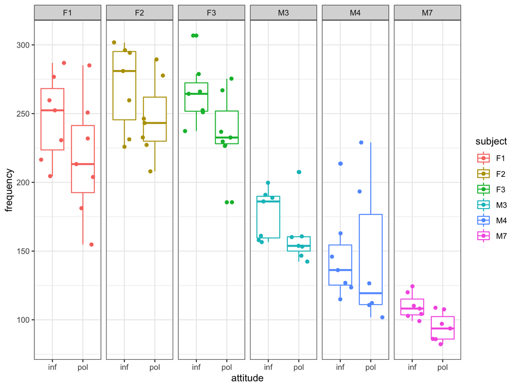

```r
library(ggplot2)
ggplot(aes(attitude, frequency, color = subject), data=d) + facet_grid(~subject) + geom_boxplot() + geom_jitter() + theme_bw()
```

# Fit linear model

- Outcome variable: frequency
- primary predictor: attitude
- important covariate varaible: gender
- $\varepsilon$: deviations from our predictions due to random factors that we cannot control experimentally

$$pitch \sim politeness + gender + \varepsilon$$

# Linear model in R

```r
lmFit <- lm(frequency ~ attitude + gender, data = d)
summary(lmFit)
```

```
##
## Call:
## lm(formula = frequency ~ attitude + gender, data = d)
##
## Residuals:
##     Min      1Q  Median      3Q     Max
## -82.409 -26.561  -4.262  24.690 100.140
##
## Coefficients:
##             Estimate Std. Error t value Pr(>|t|)
## (Intercept)  256.762      6.756  38.006   <2e-16 ***
## attitudepol  -19.553      7.833  -2.496   0.0146 *
## genderM     -108.349      7.833 -13.832   <2e-16 ***
## ---
## Signif. codes:  0 '***' 0.001 '**' 0.01 '*' 0.05 '.' 0.1 ' ' 1
##
## Residual standard error: 35.68 on 80 degrees of freedom
##   (1 observation deleted due to missingness)
## Multiple R-squared:  0.7109, Adjusted R-squared:  0.7037
## F-statistic: 98.38 on 2 and 80 DF,  p-value: < 2.2e-16
```

Note: 1 observation deleted due to missingness

# Problem with linear model

- independence: since each subject gave multiple responses, multiple responses from the same subject cannot be regarded as independent from each other.
- under the same scenario, people should also react similarly, not totally independent.

# data independence

```r
pol_subj = subset(d, attitude == "pol")
inf_subj = subset(d, attitude == "inf")
pol_subj$attitude <- NULL
inf_subj$attitude <- NULL
names(pol_subj)[names(pol_subj) == "frequency"] <- "frequency_pol"
names(inf_subj)[names(inf_subj) == "frequency"] <- "frequency_inf"

subj_merge <- merge(pol_subj, inf_subj)
head(subj_merge)
```

```
##   subject gender scenario scenario0 frequency_pol frequency_inf
## 1      F1      F        1         1         213.3         204.5
## 2      F1      F        2         2         285.1         259.7
## 3      F1      F        3         3         203.9         286.9
## 4      F1      F        4         4         250.8         276.8
## 5      F1      F        5         5         231.9         252.4
## 6      F1      F        6         6         181.2         230.7
```

# Subject dependence

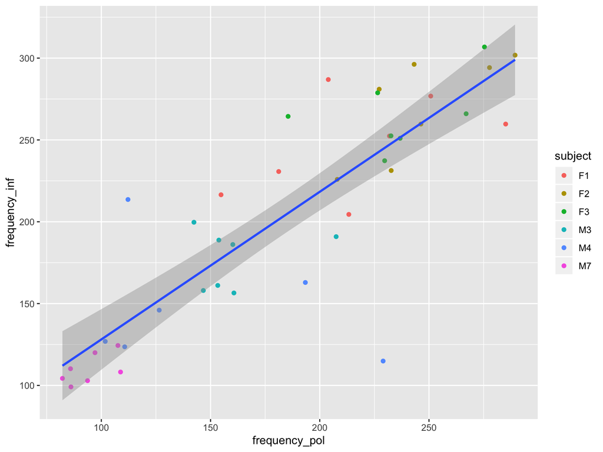

```r
ggplot(data=subj_merge, aes(frequency_pol, frequency_inf)) +
  geom_point(aes(col=subject)) +
  geom_smooth(method="lm")
```

# Subject dependence

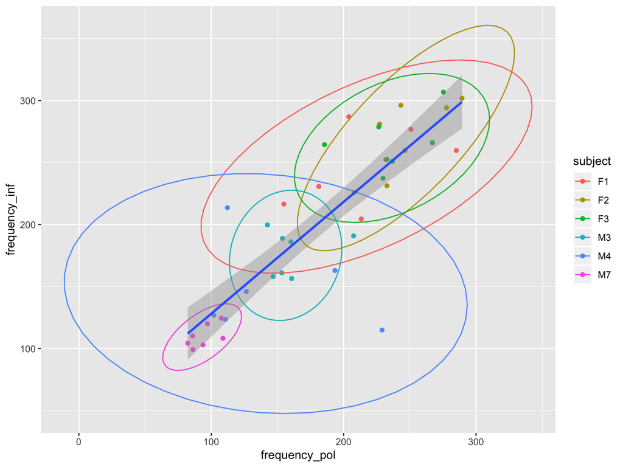

```r
ggplot(data=subj_merge, aes(frequency_pol, frequency_inf)) +
  geom_point(aes(col=subject)) +
  stat_ellipse(aes(col=subject)) +
  geom_smooth(method="lm")
```

# scenario independence

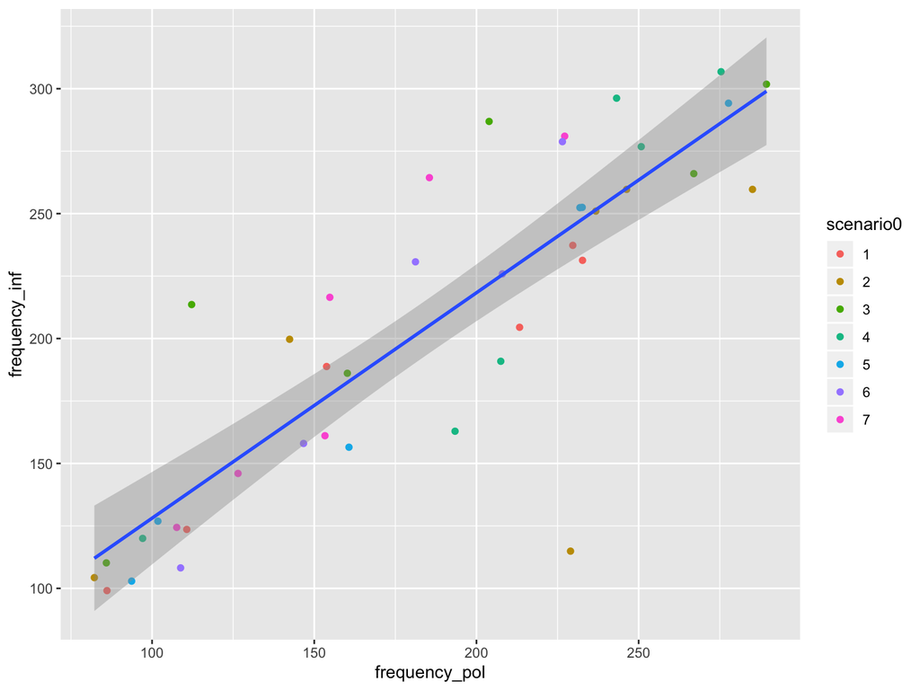

```r
ggplot(data=subj_merge, aes(frequency_pol, frequency_inf)) +
  geom_point(aes(col=scenario0)) +
  geom_smooth(method="lm")
```

# scenario independence

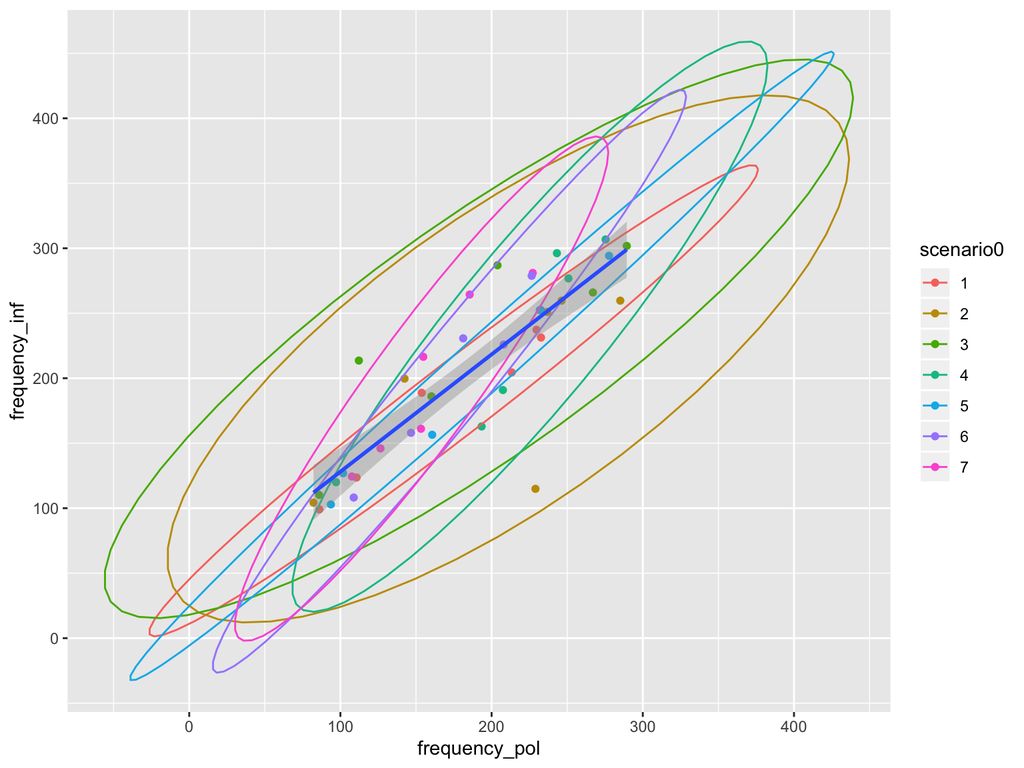

```r
ggplot(data=subj_merge, aes(frequency_pol, frequency_inf)) +
  geom_point(aes(col=scenario0)) +
  stat_ellipse(aes(col=scenario0)) +
  geom_smooth(method="lm")
```

# Mixed model

- Linear model is “fixed-effects only” model
  - one or more fixed effects
  - a general error term $\varepsilon$
  - error term is considered no structure.
- Mixed model is a mixture of fixed effect and random effect
  - Fixed effects: the independent variables that are normally included in your analyses. For instance: gender, age, your study conditions
  - Random effects: the variables that are specific to your data sample. (E.g Subject)

# Random effect

- add a random effect for subject
- allows us to resolve this non-independence data structure for each subject
- allows missing data

# Random Intercepts

- linear model
  $$pitch \sim politeness + gender + \varepsilon$$
- linear model with random effect (random intercept)
  $$pitch \sim politeness + gender + (1|subject) + \varepsilon$$
  $(1|subject)$ is the R syntax for a random intercept.
- intercepts are different for each subject
- “1” stands for the intercept in R
- this formula indicates multiple responses per subject
- resolves the non-independence multiple responses by the same subject
- the formula still contains a general error term $\varepsilon$

# Fit linear mixed model in R

- In R, lmer() function in lme4 package will do the job

```r
lm(frequency ~ attitude, data = d)
```

```
##
## Call:
## lm(formula = frequency ~ attitude, data = d)
##
## Coefficients:
## (Intercept)  attitudepol
##      202.59       -18.23
```

```r
library(lme4)
library(lmerTest) ## this package helps provide a p-value
tryCatch({lmer(frequency ~ attitude, data = d)}, error=function(e) print(e))
```

```
## <simpleError: No random effects terms specified in formula>
```

- You have to specify random effect

# Fit linear mixed model in R

```r
rs_subj_reml = lmer(frequency ~ attitude + (1 | subject), data = d)
summary(rs_subj_reml)
```

```
## Linear mixed model fit by REML. t-tests use Satterthwaite's method [
## lmerModLmerTest]
## Formula: frequency ~ attitude + (1 | subject)
##    Data: d
##
## REML criterion at convergence: 804.7
##
## Scaled residuals:
##     Min      1Q  Median      3Q     Max
## -2.2953 -0.6018 -0.2005  0.4774  3.1772
##
## Random effects:
##  Groups   Name        Variance Std.Dev.
##  subject  (Intercept) 3982     63.10
##  Residual              851     29.17
## Number of obs: 83, groups:  subject, 6
##
## Fixed effects:
##             Estimate Std. Error      df t value Pr(>|t|)
## (Intercept)  202.588     26.151   5.150   7.747 0.000501 ***
## attitudepol  -19.376      6.407  76.003  -3.024 0.003399 **
## ---
## Signif. codes:  0 '***' 0.001 '**' 0.01 '*' 0.05 '.' 0.1 ' ' 1
##
## Correlation of Fixed Effects:
##             (Intr)
## attitudepol -0.121
```

# Further explore rs_subj_reml

```r
coef(rs_subj_reml)
```

```
## $subject
##    (Intercept) attitudepol
## F1    241.1352   -19.37584
## F2    266.8920   -19.37584
## F3    259.5540   -19.37584
## M3    179.0262   -19.37584
## M4    155.6906   -19.37584
## M7    113.2306   -19.37584
##
## attr(,"class")
## [1] "coef.mer"
```

```r
AIC(rs_subj_reml)
```

```
## [1] 812.7023
```

# How to write the linear mixed model mathmatically

$$Y_{ijk} = \mu + \beta_j + \alpha_i + \varepsilon_{ijk}$$

- $i$: subject index
- $j$: attitude index
- $k$: scenario index
- $\mu$: intercept
- $\beta_j$: attitude coefficient of $j^{th}$ group
- $\alpha_i \sim N(0, \sigma^2_\alpha)$: random intercept for the $i^{th}$ subject
- $\varepsilon_{ijk} \sim N(0, \sigma^2)$:

# Fit linear mixed model in R (REML = FALSE)

```r
rs_subj_ml = lmer(frequency ~ attitude + (1 | subject), REML = FALSE, data = d)
summary(rs_subj_ml)
```

```
## Linear mixed model fit by maximum likelihood . t-tests use Satterthwaite's
##   method [lmerModLmerTest]
## Formula: frequency ~ attitude + (1 | subject)
##    Data: d
##
##      AIC      BIC   logLik deviance df.resid
##    826.5    836.2   -409.3    818.5       79
##
## Scaled residuals:
##     Min      1Q  Median      3Q     Max
## -2.3067 -0.6051 -0.2042  0.4793  3.1931
##
## Random effects:
##  Groups   Name        Variance Std.Dev.
##  subject  (Intercept) 3308.7   57.52
##  Residual              839.9   28.98
## Number of obs: 83, groups:  subject, 6
##
## Fixed effects:
##             Estimate Std. Error      df t value Pr(>|t|)
## (Intercept)  202.588     23.905   6.214   8.475 0.000122 ***
## attitudepol  -19.372      6.365  77.003  -3.043 0.003199 **
## ---
## Signif. codes:  0 '***' 0.001 '**' 0.01 '*' 0.05 '.' 0.1 ' ' 1
##
## Correlation of Fixed Effects:
##             (Intr)
## attitudepol -0.131
```

REML represents restricted maximum likelihood

- if REML=FALSE, maximum likelihood estimation will be used
- its estimation does not base estimates on a maximum likelihood fit of all the information
- but instead uses a likelihood function calculated from a transformed set of data
- nuisance parameters have no effect.

# Compare to linear model

```r
summary(lm(frequency ~ attitude, data = d))
```

```
##
## Call:
## lm(formula = frequency ~ attitude, data = d)
##
## Residuals:
##      Min       1Q   Median       3Q      Max
## -103.488  -62.122    9.044   51.178  105.044
##
## Coefficients:
##             Estimate Std. Error t value Pr(>|t|)
## (Intercept)   202.59      10.08  20.107   <2e-16 ***
## attitudepol   -18.23      14.34  -1.272    0.207
## ---
## Signif. codes:  0 '***' 0.001 '**' 0.01 '*' 0.05 '.' 0.1 ' ' 1
##
## Residual standard error: 65.3 on 81 degrees of freedom
##   (1 observation deleted due to missingness)
## Multiple R-squared:  0.01958,    Adjusted R-squared:  0.007475
## F-statistic: 1.618 on 1 and 81 DF,  p-value: 0.2071
```

Without adjusting for random effect, attitude won’t be a significant predictor.

# Getting p-values

```r
rs_subj_reml = lmer(frequency ~ attitude + (1 | subject), data = d)
anova(rs_subj_reml, ddf = "Kenward-Roger")
```

```
## Type III Analysis of Variance Table with Kenward-Roger's method
##          Sum Sq Mean Sq NumDF  DenDF F value   Pr(>F)
## attitude 7782.8  7782.8     1 76.002  9.1456 0.003399 **
## ---
## Signif. codes:  0 '***' 0.001 '**' 0.01 '*' 0.05 '.' 0.1 ' ' 1
```

```r
## likelihood ratio test: comparing full model and reduced model
## get the p-value for reduced variable
## have to use REML = FALSE
rs_subj_ml = lmer(frequency ~ attitude + (1 | subject), REML = FALSE, data = d)
rs_null_ml = lmer(frequency ~ 1 + (1 | subject), REML = FALSE, data = d)

anova(rs_null_ml, rs_subj_ml)
```

```
## Data: d
## Models:
## rs_null_ml: frequency ~ 1 + (1 | subject)
## rs_subj_ml: frequency ~ attitude + (1 | subject)
##            Df    AIC    BIC  logLik deviance  Chisq Chi Df Pr(>Chisq)
## rs_null_ml  3 833.25 840.51 -413.62   827.25
## rs_subj_ml  4 826.51 836.18 -409.25   818.51 8.7444      1   0.003106 **
## ---
## Signif. codes:  0 '***' 0.001 '**' 0.01 '*' 0.05 '.' 0.1 ' ' 1
```

# add another covariate gender and its interaction with attitude

```r
summary(lmer(frequency ~ attitude * gender +  (1 | subject), data = d))
```

```
## Linear mixed model fit by REML. t-tests use Satterthwaite's method [
## lmerModLmerTest]
## Formula: frequency ~ attitude * gender + (1 | subject)
##    Data: d
##
## REML criterion at convergence: 778.2
##
## Scaled residuals:
##     Min      1Q  Median      3Q     Max
## -2.2334 -0.5105 -0.1551  0.4738  3.0875
##
## Random effects:
##  Groups   Name        Variance Std.Dev.
##  subject  (Intercept) 605.4    24.61
##  Residual             844.1    29.05
## Number of obs: 83, groups:  subject, 6
##
## Fixed effects:
##                     Estimate Std. Error       df t value Pr(>|t|)
## (Intercept)          260.686     15.557    4.754  16.757 2.07e-05 ***
## attitudepol          -27.400      8.966   75.009  -3.056  0.00311 **
## genderM             -116.195     22.000    4.754  -5.282  0.00376 **
## attitudepol:genderM   16.190     12.763   75.018   1.269  0.20852
## ---
## Signif. codes:  0 '***' 0.001 '**' 0.01 '*' 0.05 '.' 0.1 ' ' 1
##
## Correlation of Fixed Effects:
##             (Intr) atttdp gendrM
## attitudepol -0.288
## genderM     -0.707  0.204
## atttdpl:gnM  0.202 -0.703 -0.286
```

# Investigate scenario

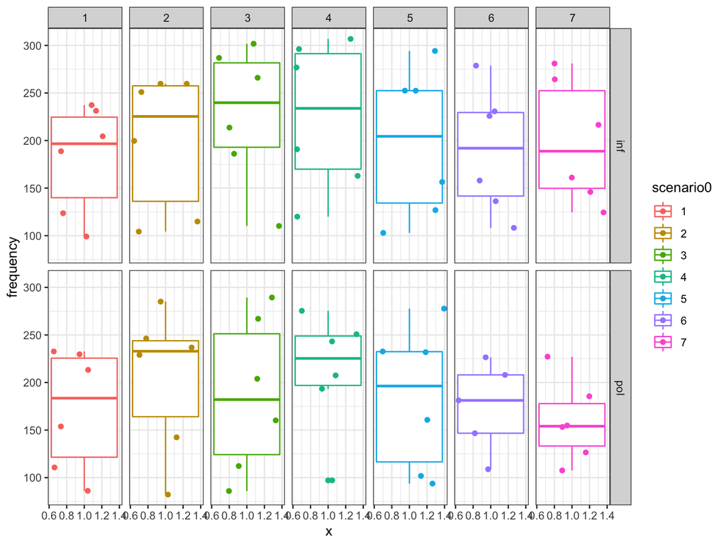

```r
ggplot(aes(1, frequency, col=scenario0), data=d) +
  geom_boxplot() +
  geom_jitter() +
  facet_grid(attitude ~ scenario0)  +
  theme_bw()
```

# A larger mixed model

```r
rs_intergen_subjscene_ml = lmer(frequency ~ attitude + gender + (1 | subject) +
    (1 | scenario), REML = FALSE, data = d)
summary(rs_intergen_subjscene_ml)
```

```
## Linear mixed model fit by maximum likelihood . t-tests use Satterthwaite's
##   method [lmerModLmerTest]
## Formula: frequency ~ attitude + gender + (1 | subject) + (1 | scenario)
##    Data: d
##
##      AIC      BIC   logLik deviance df.resid
##    807.1    821.6   -397.6    795.1       77
##
## Scaled residuals:
##     Min      1Q  Median      3Q     Max
## -2.2958 -0.6456 -0.0777  0.5449  3.5121
##
## Random effects:
##  Groups   Name        Variance Std.Dev.
##  scenario (Intercept) 205.2    14.32
##  subject  (Intercept) 417.1    20.42
##  Residual             637.4    25.25
## Number of obs: 83, groups:  scenario, 7; subject, 6
##
## Fixed effects:
##             Estimate Std. Error       df t value Pr(>|t|)
## (Intercept)  256.847     13.828    8.497  18.575 3.55e-08 ***
## attitudepol  -19.722      5.547   70.920  -3.555 0.000677 ***
## genderM     -108.517     17.573    5.928  -6.175 0.000868 ***
## ---
## Signif. codes:  0 '***' 0.001 '**' 0.01 '*' 0.05 '.' 0.1 ' ' 1
##
## Correlation of Fixed Effects:
##             (Intr) atttdp
## attitudepol -0.201
## genderM     -0.635  0.004
```

# A larger mixed model

```r
coef(rs_intergen_subjscene_ml)
```

```
## $scenario
##   (Intercept) attitudepol   genderM
## 1    243.4865   -19.72206 -108.5173
## 2    263.3589   -19.72206 -108.5173
## 3    268.1317   -19.72206 -108.5173
## 4    277.2536   -19.72206 -108.5173
## 5    254.9320   -19.72206 -108.5173
## 6    244.8021   -19.72206 -108.5173
## 7    245.9623   -19.72206 -108.5173
##
## $subject
##    (Intercept) attitudepol   genderM
## F1    243.3681   -19.72206 -108.5173
## F2    266.9444   -19.72206 -108.5173
## F3    260.2277   -19.72206 -108.5173
## M3    284.3541   -19.72206 -108.5173
## M4    262.0576   -19.72206 -108.5173
## M7    224.1286   -19.72206 -108.5173
##
## attr(,"class")
## [1] "coef.mer"
```

# Random Slopes

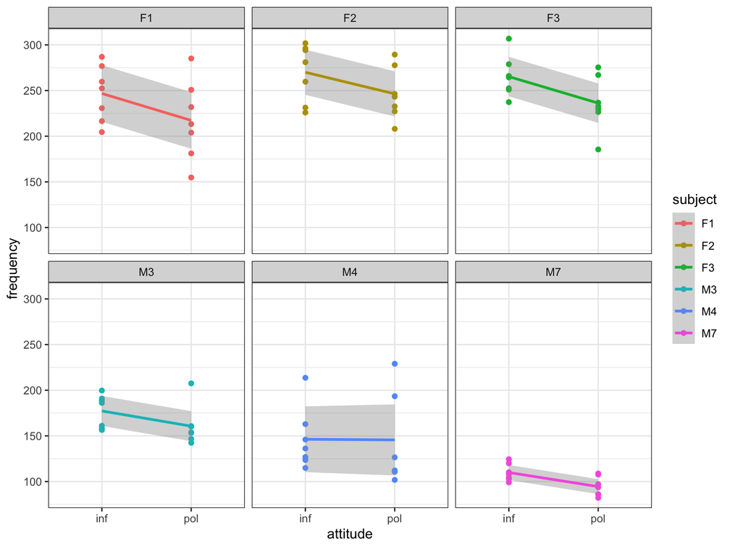

```r
ggplot(aes(attitude, frequency, color = subject), data=d) +
  geom_point() +
  geom_smooth(method="lm", aes(group=1)) +
  facet_wrap(~subject ) +
  theme_bw()
```

# Random Slopes

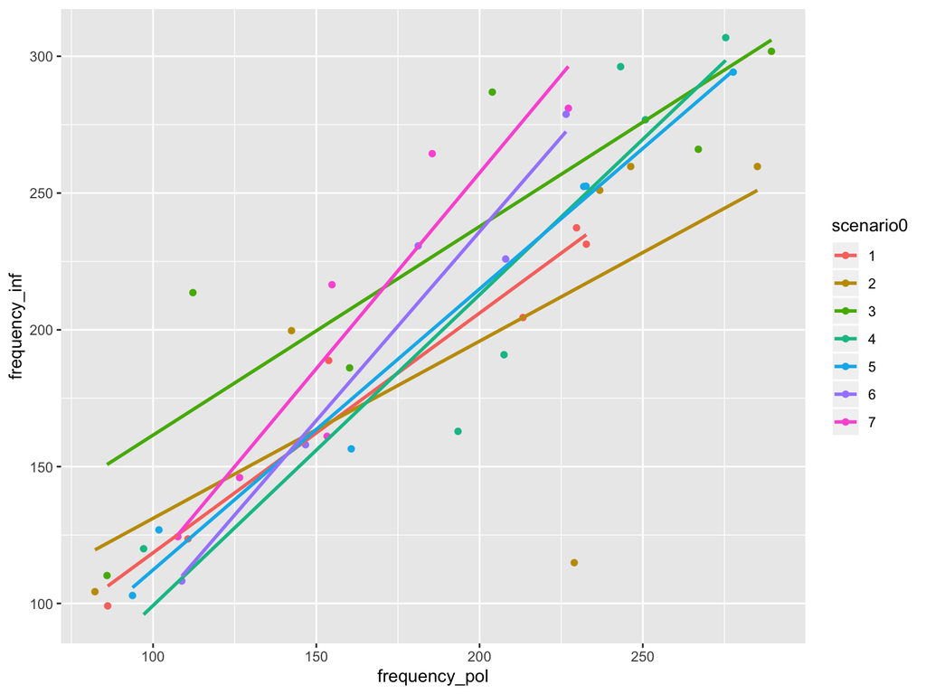

```r
ggplot(data=subj_merge, aes(frequency_pol, frequency_inf, col=scenario0)) +
  geom_point() +
  geom_smooth(method="lm", se = F)
```

# Random Slopes in R

```r
politeness.model.rs = lmer(frequency ~  attitude + gender + (1 + attitude | subject) +
    (1 | scenario), REML = FALSE, data = d)
```

```
## boundary (singular) fit: see ?isSingular
```

```r
summary(politeness.model.rs)
```

```
## Linear mixed model fit by maximum likelihood . t-tests use Satterthwaite's
##   method [lmerModLmerTest]
## Formula: frequency ~ attitude + gender + (1 + attitude | subject) + (1 |
##     scenario)
##    Data: d
##
##      AIC      BIC   logLik deviance df.resid
##    811.1    830.4   -397.5    795.1       75
##
## Scaled residuals:
##     Min      1Q  Median      3Q     Max
## -2.2800 -0.6555 -0.0803  0.5369  3.5016
##
## Random effects:
##  Groups   Name        Variance Std.Dev. Corr
##  scenario (Intercept) 205.052  14.320
##  subject  (Intercept) 395.469  19.886
##           attitudepol   1.251   1.118   1.00
##  Residual             637.069  25.240
## Number of obs: 83, groups:  scenario, 7; subject, 6
##
## Fixed effects:
##             Estimate Std. Error       df t value Pr(>|t|)
## (Intercept)  257.802     13.683    7.975  18.842 6.75e-08 ***
## attitudepol  -19.715      5.565   58.506  -3.543 0.000785 ***
## genderM     -110.428     17.531    5.927  -6.299 0.000782 ***
## ---
## Signif. codes:  0 '***' 0.001 '**' 0.01 '*' 0.05 '.' 0.1 ' ' 1
##
## Correlation of Fixed Effects:
##             (Intr) atttdp
## attitudepol -0.153
## genderM     -0.641  0.003
## convergence code: 0
## boundary (singular) fit: see ?isSingular
```

# Random Slopes in R

```r
coef(politeness.model.rs)
```

```
## $scenario
##   (Intercept) attitudepol   genderM
## 1    244.4392   -19.71467 -110.4277
## 2    264.3110   -19.71467 -110.4277
## 3    269.0836   -19.71467 -110.4277
## 4    278.2053   -19.71467 -110.4277
## 5    255.8843   -19.71467 -110.4277
## 6    245.7753   -19.71467 -110.4277
## 7    246.9149   -19.71467 -110.4277
##
## $subject
##    (Intercept) attitudepol   genderM
## F1    243.7394   -20.50555 -110.4277
## F2    266.7317   -19.21246 -110.4277
## F3    260.1367   -19.58336 -110.4277
## M3    285.4172   -18.16159 -110.4277
## M4    263.9094   -19.37119 -110.4277
## M7    226.8772   -21.45387 -110.4277
##
## attr(,"class")
## [1] "coef.mer"
```

# Is random slope necessary

```r
rs_gen_subjscene_con_reml = lmer(frequency ~ attitude + gender + (1 + attitude |
    subject) + (1 | scenario), REML = TRUE, data = d)
```

```
## boundary (singular) fit: see ?isSingular
```

```r
rs_gen_subjscene_reml = lmer(frequency ~ attitude + gender + (1 | subject) + (1 |
    scenario), REML = TRUE, data = d)

anova(rs_gen_subjscene_reml, rs_gen_subjscene_con_reml)
```

```
## refitting model(s) with ML (instead of REML)
```

```
## Data: d
## Models:
## rs_gen_subjscene_reml: frequency ~ attitude + gender + (1 | subject) + (1 | scenario)
## rs_gen_subjscene_con_reml: frequency ~ attitude + gender + (1 + attitude | subject) + (1 |
## rs_gen_subjscene_con_reml:     scenario)
##                           Df    AIC    BIC  logLik deviance  Chisq Chi Df
## rs_gen_subjscene_reml      6 807.10 821.61 -397.55   795.10
## rs_gen_subjscene_con_reml  8 811.07 830.42 -397.54   795.07 0.0275      2
##                           Pr(>Chisq)
## rs_gen_subjscene_reml
## rs_gen_subjscene_con_reml     0.9863
```

- it appears that we don’t need to include random slope for condition in the model
- however, others would argue that we should keep our models maximal

# Beyond linear mixed model

If the outcome variable is

- Continuous: use a linear regression model with mixed effects
- Binary: use a logistic regression model with mixed effects
- Count: use a Poisson/negative binomial regression model with mixed effects

Function lmer is used to fit linear mixed models, function glmer is used to fit generalized (non-Gaussian) linear mixed models.

# Another example sleep study

```r
sleepStudy <- read.table("https://caleb-huo.github.io/teaching/data/sleep/sleepstudy.txt", header=T, row.names = 1)
sleepStudy$Subject <- as.factor(sleepStudy$Subject)

head(sleepStudy, n=10)
```

```
##    Reaction Days Subject
## 1  249.5600    0     308
## 2  258.7047    1     308
## 3  250.8006    2     308
## 4  321.4398    3     308
## 5  356.8519    4     308
## 6  414.6901    5     308
## 7  382.2038    6     308
## 8  290.1486    7     308
## 9  430.5853    8     308
## 10 466.3535    9     308
```

```r
str(sleepStudy)
```

```
## 'data.frame':    180 obs. of  3 variables:
##  $ Reaction: num  250 259 251 321 357 ...
##  $ Days    : int  0 1 2 3 4 5 6 7 8 9 ...
##  $ Subject : Factor w/ 18 levels "308","309","310",..: 1 1 1 1 1 1 1 1 1 1 ...
```

# Sleep deprivation data

- This laboratory experiment measured the effect of sleep deprivation on cognitive performance.
- There were 18 subjects, chosen from the population of interest (long-distance truck drivers), in the 10 day trial. These subjects were restricted to 3 hours sleep per night during the trial.
- On each day of the trial each subject’s reaction time was measured. The reaction time shown here is the average of several measurements.
- These data are balanced in that each subject is measured the same number of times and on the same occasions.

# Simple longitudinal data

- Repeated measures data consist of measurements of a response (and, perhaps, some covariates) on several experimental (or observational) units.
- Longitudinal data are repeated measures data in which the observations are taken over time.
- We wish to characterize the response over time within subjects and the variation in the time trends between subjects.

# Data exploratory

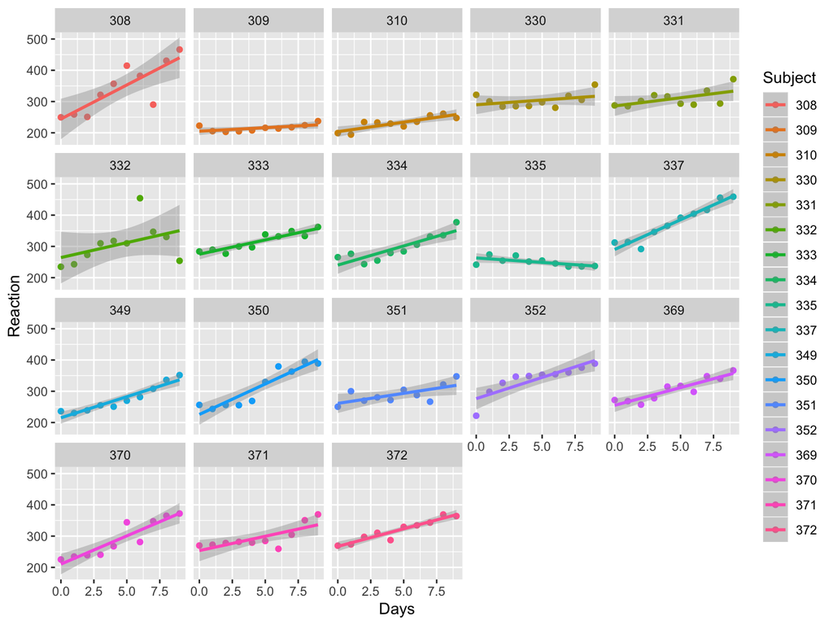

```r
ggplot(aes(Days, Reaction, col=Subject), data = sleepStudy) + geom_point() + geom_smooth(method="lm") + facet_wrap(~Subject)
```

# Fit linear mixed model in R

```r
fm1 <- lmer(Reaction ~ Days + (Days|Subject), sleepstudy)
summary(fm1)
```

```
## Linear mixed model fit by REML. t-tests use Satterthwaite's method [
## lmerModLmerTest]
## Formula: Reaction ~ Days + (Days | Subject)
##    Data: sleepstudy
##
## REML criterion at convergence: 1743.6
##
## Scaled residuals:
##     Min      1Q  Median      3Q     Max
## -3.9536 -0.4634  0.0231  0.4633  5.1793
##
## Random effects:
##  Groups   Name        Variance Std.Dev. Corr
##  Subject  (Intercept) 611.90   24.737
##           Days         35.08    5.923   0.07
##  Residual             654.94   25.592
## Number of obs: 180, groups:  Subject, 18
##
## Fixed effects:
##             Estimate Std. Error      df t value Pr(>|t|)
## (Intercept)  251.405      6.824  17.005  36.843  < 2e-16 ***
## Days          10.467      1.546  16.995   6.771 3.27e-06 ***
## ---
## Signif. codes:  0 '***' 0.001 '**' 0.01 '*' 0.05 '.' 0.1 ' ' 1
##
## Correlation of Fixed Effects:
##      (Intr)
## Days -0.138
```

# coef

```r
coef(fm1)
```

```
## $Subject
##     (Intercept)       Days
## 308    253.6626 19.6665597
## 309    211.0108  1.8467699
## 310    212.4488  5.0177063
## 330    275.0940  5.6531411
## 331    273.6636  7.3976093
## 332    260.4439 10.1952325
## 333    268.2441 10.2438881
## 334    244.1731 11.5417935
## 335    251.0724 -0.2851939
## 337    286.2916 19.0963068
## 349    226.1971 11.6403856
## 350    238.3357 17.0815045
## 351    255.9828  7.4520035
## 352    272.2666 14.0036922
## 369    254.6802 11.3395736
## 370    225.7940 15.2895377
## 371    252.2122  9.4791130
## 372    263.7185 11.7515240
##
## attr(,"class")
## [1] "coef.mer"
```

# generate .R file

```r
knitr::purl("mixedModel.rmd", output = "mixedModel.R ", documentation = 2)
```

```
##
##
## processing file: mixedModel.rmd
```

[output not shown]

```
## output file: mixedModel.R
```

```
## [1] "mixedModel.R "
```